# DRN Cell Types Project: Comparison with Linnarsson Dataset - Data Conversion

Kee Wui Huang, Sabatini Lab (Harvard Medical School)

22 August, 2019

# Notebook Overiew

This notebook is a part of a series that documents the review analysis for the DRN Cell Types project.

This notebook contains the code used to convert the RNA-seq data from Zeisel et al. (2018) from the loom format into a Seurat object to make it suitable for comparison with our DRN inDrop dataset.

# Analysis Workflow

## 1. Load libraries and data object

```r
library(devtools)
library(useful)
library(dplyr)
library(Matrix)
library(R6)
library(hdf5r)
library(loomR)
```

Load the loom data file from the Zeisel et al. (2018) dataset:

```r
lfile <- connect(filename = "/Volumes/LaCie/Dropbox/Sabatini Lab/DRN Cell Types Project/DRN Cell Types Manuscript/Revisions (1)/RNA-seq/l6_r3_cholinergic_monoaminergic_and_peptidergic_neurons.loom")
lfile
```

```
Class: loom
Filename: /Volumes/LaCie/Dropbox/Sabatini Lab/DRN Cell Types Project/DRN Cell Types Manuscript/Revisions (1)/RNA-seq/l6_r3_cholinergic_monoaminergic_and_peptidergic_neurons.loom
Access type: H5F_ACC_RDONLY
Attributes: CreationDate, last_modified
Listing:
       name    obj_type dataset.dims dataset.type_class
  col_attrs   H5I_GROUP         <NA>               <NA>
 col_graphs   H5I_GROUP         <NA>               <NA>
     layers   H5I_GROUP         <NA>               <NA>
     matrix H5I_DATASET 3977 x 27998          H5T_FLOAT
  row_attrs   H5I_GROUP         <NA>               <NA>
 row_graphs   H5I_GROUP         <NA>               <NA>
```

loom object has 3,977 cells x 27,998 genes.

## 2. Find and fetch relevant fields in the loom object

### 2.1 Count matrix

```r
lfile[["matrix"]]
```

```
Class: H5D
Dataset: /matrix
Filename: /Volumes/LaCie/Dropbox/Sabatini Lab/DRN Cell Types Project/DRN Cell Types Manuscript/Revisions (1)/RNA-seq/l6_r3_cholinergic_monoaminergic_and_peptidergic_neurons.loom
Access type: H5F_ACC_RDONLY
Datatype: H5T_IEEE_F32LE
Space: Type=Simple     Dims=3977 x 27998     Maxdims=Inf x 27998
Chunk: 36 x 64
```

Check that `lfile$matrix` is a data matrix:

```r
corner(lfile$matrix[,])
```

```
     [,1] [,2] [,3] [,4] [,5]
[1,]    6    0    0    0    2
[2,]    4    0    1    2    0
[3,]    6    0    1    0    0
[4,]    0    0    1    0    0
[5,]    0    0    1    1    0
```

Export the expression matrix and format it to Genes x Cells:

```r
zeisel.expr <- lfile$matrix[,]
zeisel.expr <- t(zeisel.expr)
dim(zeisel.expr)
```

```
[1] 27998  3977
```

```r
corner(zeisel.expr)
```

```
     [,1] [,2] [,3] [,4] [,5]
[1,]    6    4    6    0    0
[2,]    0    0    0    0    0
[3,]    0    1    1    1    1
[4,]    0    2    0    0    1
[5,]    2    0    0    0    0
```

### 2.2 Column data (cells)

Check how many column atrributes there are:

```r
length(lfile$col.attrs)
```

```
[1] 127
```

```r
lfile$col.attrs
```

[output not shown]

[output cut: 1609 more lines]

```

$ngperul_cDNA
Class: H5D
Dataset: /col_attrs/ngperul_cDNA
Filename: /Volumes/LaCie/Dropbox/Sabatini Lab/DRN Cell Types Project/DRN Cell Types Manuscript/Revisions (1)/RNA-seq/l6_r3_cholinergic_monoaminergic_and_peptidergic_neurons.loom
Access type: H5F_ACC_RDONLY
Attributes: last_modified
Datatype: H5T_STRING {
      STRSIZE 3;
      STRPAD H5T_STR_NULLPAD;
      CSET H5T_CSET_ASCII;
      CTYPE H5T_C_S1;
   }
Space: Type=Simple     Dims=3977     Maxdims=3977
Not chunked
```

#### 2.2.1 Sex

```r
table(lfile$col.attrs$Sex[])
```

```
    ?    1F    1M 1M 1F    2M 2M 1F     F     M  M, F
    4  1186   569   689     5     1  1425    90     8
```

Not sure why there are so many categories here. Will not include this metadata field for now.

#### 2.2.2 Cell IDs

```r
length(lfile$col.attrs$CellID[])
```

```
[1] 3977
```

```r
head(lfile$col.attrs$CellID[])
```

```
[1] "10X54_4_GAATGGTCTGATCA-"  "10X54_4_AGAAATCAAAGTAG-"  "10X55_3_TTCTACAGATGAGC-"
[4] "10X33_2_GTTCAGGAGGTTCA-1" "10X54_2_TCTGAGTAAACCTC-"  "10X55_8_CTCCTGTTTGTGTG-"
```

Fetch the cell IDs:

```r
zeisel.cellIDs <- lfile$col.attrs$CellID[]
length(zeisel.cellIDs)
```

```
[1] 3977
```

```r
head(zeisel.cellIDs)
```

```
[1] "10X54_4_GAATGGTCTGATCA-"  "10X54_4_AGAAATCAAAGTAG-"  "10X55_3_TTCTACAGATGAGC-"
[4] "10X33_2_GTTCAGGAGGTTCA-1" "10X54_2_TCTGAGTAAACCTC-"  "10X55_8_CTCCTGTTTGTGTG-"
```

```r
table(table(zeisel.cellIDs))  # make sure that all values are unique (all 1's)
```

```
   1
3977
```

#### 2.2.3 Cluster names

```r
head(lfile$col.attrs$ClusterName[])
```

```
[1] "HBSER4" "HBSER4" "HBSER4" "HBSER4" "HBSER4" "HBSER4"
```

Fetch the cluster names:

```r
zeisel.clusterNames <- lfile$col.attrs$ClusterName[]
length(zeisel.clusterNames)
```

```
[1] 3977
```

```r
head(zeisel.clusterNames)
```

```
[1] "HBSER4" "HBSER4" "HBSER4" "HBSER4" "HBSER4" "HBSER4"
```

```r
table(zeisel.clusterNames)
```

```
zeisel.clusterNames
 DECHO1  DEINH4  DEINH5  DEINH6  DEINH7  DEINH8   HBADR  HBCHO3  HBCHO4   HBNOR  HBSER1  HBSER2  HBSER3
    114      57     308      12     182     120      40      72      52      23     105     109      87
 HBSER4  HBSER5  HYPEP1  HYPEP2  HYPEP3  HYPEP4  HYPEP5  HYPEP6  HYPEP7  HYPEP8  MBDOP1  MBDOP2 MEGLU14
     72      64     191      43     152      98     173      32      13      15      57      63      47
MEINH14 SCINH11   TECHO  TEINH2  TEINH3
     21      50     121    1339     145
```

Only 105 neurons in the cluster HBSER1, which is the cluster that they have predicted as being from the DRN/CLi/B9/MRN and likely contains R1-derived 5-HT neurons based on enrichment of *En1*.

Check what `$Cluster` is:

```r
table(lfile$col.attrs$Clusters[])
```

```
   0    1    2    3    4    5    6    7    8    9   10   11   12   13   14   15   16   17   18   19
  72   64  109  105   87   13   15   50  145   21  152   57  308 1339   12   43  191  182  120   57
  20   21   22   23   24   25   26   27   28   29   30
  32   63   23   40   47  173   98  114  121   52   72
```

Can’t really tell what this field is. Will leave this out for now.

#### 2.2.4 Tissue

```r
table(lfile$col.attrs$Tissue[])
```

```
     Amygd        CA1         HC     Hypoth        MBv    Medulla       Pons         SC  StriatDor
        63          1          1       1636        380        213        219         50         22
StriatVent       Thal
      1363         29
```

```r
zeisel.tissue <- lfile$col.attrs$Tissue[]
```

```r
table(lfile$col.attrs$Region[])
```

```
                              Hypothalamus                                    Medulla
                                      1453                                        207
                           Midbrain dorsal                           Midbrain ventral
                                        47                                        141
                                  Pallidum                                       Pons
                                       145                                        417
                               Spinal cord          Striatum dorsal, Striatum ventral
                                        50                                       1339
Striatum dorsal, Striatum ventral,Amygdala                                   Thalamus
                                       121                                         57
```

```r
zeisel.region <- lfile$col.attrs$Region[]
```

#### 2.2.5 Taxonomy

```r
table(lfile$col.attrs$Taxonomy_group[])
```

```
Cholinergic and monoaminergic neurons                   Peptidergic neurons
                                 1071                                  2906
```

```r
table(lfile$col.attrs$TaxonomyRank1[])
```

```
Neurons
   3977
```

```r
table(lfile$col.attrs$TaxonomyRank2[])
```

```
CNS neurons
       3977
```

```r
table(lfile$col.attrs$TaxonomyRank3[])
```

```
Cholinergic, monoaminergic and peptidergic neurons
                                              3977
```

```r
table(lfile$col.attrs$TaxonomyRank4[])
```

```
Cholinergic and monoaminergic neurons                   Peptidergic neurons
                                 1071                                  2906
```

`$TaxonomyRank4` and `$TaxonomyGroup` are the same here. `$TaxonomySymbol` is the same thing but as a 4 character string.

#### 2.2.6 Strain/Species

```r
table(lfile$col.attrs$Strain[])
```

```
       CD-1 Swiss
 3859    69    49
```

```r
table(lfile$col.attrs$Species[])
```

```
       Mm
3859  118
```

```r
zeisel.strain <- lfile$col.attrs$Strain[]
```

#### 2.2.7 Sequencing information

```r
head(lfile$col.attrs$`_Total`[])
```

```
[1]  6521  9183  8402 11525  7134  6198
```

```r
summary(lfile$col.attrs$`_Total`[])
```

```
   Min. 1st Qu.  Median    Mean 3rd Qu.    Max.
    160    2141    3338    4629    5566   40150
```

```r
head(lfile$col.attrs$`Total Genes Detected`[])
```

```
[1] "" "" "" "" "" ""
```

`_Total` appears to refer to nUMI. `CreateSeuratObject` calculates this anyway, so we can leave this out.

```r
head(lfile$col.attrs$`_Valid`[])
```

```
[1] 1 1 1 1 1 1
```

```r
table(lfile$col.attrs$`_Valid`[])
```

```
   1
3977
```

`_Valid` seems to be a flag of some sort. Not informative for us in this case since all of the values are 1.

```r
head(lfile$col.attrs$`Reads Mapped Confidently to Exonic Regions`[])
```

```
[1] "" "" "" "" "" ""
```

```r
head(lfile$col.attrs$`Number of Reads`[])
```

```
[1] "" "" "" "" "" ""
```

Most cells are lacking metadata.

### 2.3 Row data (genes)

Check how many row attributes there are:

```r
length(lfile$row.attrs)
```

```
[1] 7
```

```r
lfile[["row_attrs"]]
```

```
Class: H5Group
Filename: /Volumes/LaCie/Dropbox/Sabatini Lab/DRN Cell Types Project/DRN Cell Types Manuscript/Revisions (1)/RNA-seq/l6_r3_cholinergic_monoaminergic_and_peptidergic_neurons.loom
Group: /row_attrs
Attributes: last_modified
Listing:
      name    obj_type dataset.dims dataset.type_class
 Accession H5I_DATASET        27998         H5T_STRING
      Gene H5I_DATASET        27998         H5T_STRING
    _LogCV H5I_DATASET        27998          H5T_FLOAT
  _LogMean H5I_DATASET        27998          H5T_FLOAT
 _Selected H5I_DATASET        27998        H5T_INTEGER
    _Total H5I_DATASET        27998          H5T_FLOAT
    _Valid H5I_DATASET        27998        H5T_INTEGER
```

Fetch the gene names:

```r
zeisel.genes <- lfile$row.attrs$Gene[]
length(zeisel.genes)
```

```
[1] 27998
```

```r
head(zeisel.genes)
```

```
[1] "Pgr15l" "Fst"    "Fxyd5"  "Asah2"  "Klf14"  "Lat2"
```

Fetch the Accession IDs:

```r
zeisel.geneIDs <- lfile$row.attrs$Accession[]
length(zeisel.geneIDs)
```

```
[1] 27998
```

```r
head(zeisel.geneIDs)
```

```
[1] "ENSMUSG00000031212" "ENSMUSG00000021765" "ENSMUSG00000009687" "ENSMUSG00000024887"
[5] "ENSMUSG00000073209" "ENSMUSG00000040751"
```

```r
summary(lfile$row.attrs$`_Total`[])
```

```
    Min.  1st Qu.   Median     Mean  3rd Qu.     Max.
     0.0      0.0      8.0    441.5    212.0 443453.0
```

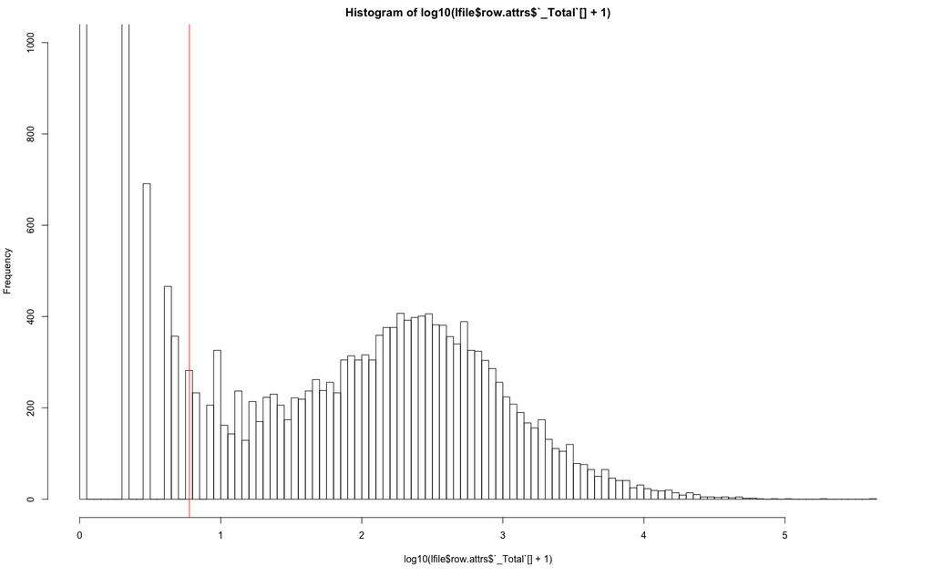

```r
hist(log10(lfile$row.attrs$`_Total`[]+1), breaks = 100, ylim = c(0, 1000))
abline(v = log10(5+1), col = "red")
```

Not sure what `_Total` actually is. We will not use it for now, and calculate anything we need from the expression matrix.

## 3. Create Seurat object from Zeisel data

### 3.1 Load the Seurat library

```r
library(Seurat)
```

### 3.2 Format the data and metadata

#### 3.2.1 Convert the expression matrix into a data frame with the gene names and cell IDs

```r
zeisel.expr <- as.data.frame(x = zeisel.expr,
                             row.names = zeisel.genes)
colnames(zeisel.expr) <- zeisel.cellIDs
```

#### 3.2.2 Combine the metadata fields into a single table (cells x features)

```r
zeisel.metadata <- data.frame(zeisel.clusterNames,
                              zeisel.tissue,
                              zeisel.region,
                              zeisel.strain)
rownames(zeisel.metadata) <- zeisel.cellIDs
```

#### 3.2.3 Filter genes

Find the maximum UMIFM in a single cell for each gene:

```r
gene.max.UMI.per.cell <- as.data.frame(apply(zeisel.expr, 1, FUN = max))
```

```r
summary(gene.max.UMI.per.cell)
```

```
 apply(zeisel.expr, 1, FUN = max)
 Min.   :   0.000
 1st Qu.:   0.000
 Median :   1.000
 Mean   :   6.042
 3rd Qu.:   5.000
 Max.   :8052.000
```

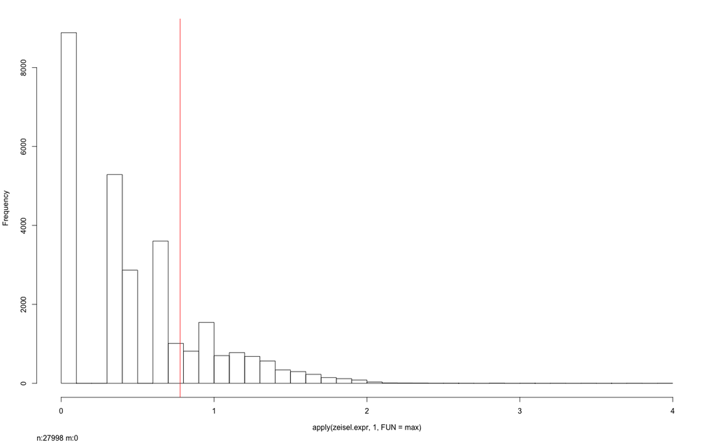

```r
hist(log10(gene.max.UMI.per.cell+1), breaks = 100)
abline(v = log10(5+1), col = "red")
```

Check how many genes pass different thresholds:

```r
sum(gene.max.UMI.per.cell > 0)
```

```
[1] 19114
```

```r
sum(gene.max.UMI.per.cell > 1)
```

```
[1] 13825
```

```r
sum(gene.max.UMI.per.cell > 2)
```

```
[1] 10959
```

Set a threshold and filter the genes:

```r
gene.thresh <- 1
zeisel.expr.filtered <- zeisel.expr[(gene.max.UMI.per.cell>gene.thresh),]
dim(zeisel.expr.filtered)
```

```
[1] 13825  3977
```

### 3.3 Create the Seurat object

```r
zeisel.ob <- CreateSeuratObject(raw.data = zeisel.expr.filtered,
                                meta.data = zeisel.metadata,
                                min.cells = 1,
                                min.genes = 0)
zeisel.ob <- MakeSparse(object = zeisel.ob)
dim(zeisel.ob@data)
```

```
[1] 13825  3977
```

```r
rm(zeisel.expr)
rm(zeisel.metadata)
```

```r
colnames(zeisel.ob@meta.data)
```

```
[1] "nGene"               "nUMI"                "zeisel.clusterNames" "zeisel.tissue"
[5] "zeisel.region"       "zeisel.strain"       "orig.ident"          "percent.mito"
```

```r
zeisel.ob <- SetAllIdent(object = zeisel.ob,
                         id = "zeisel.clusterNames")
```

```r
table(zeisel.ob@ident)
```

```
 DECHO1  DEINH4  DEINH5  DEINH6  DEINH7  DEINH8   HBADR  HBCHO3  HBCHO4   HBNOR  HBSER1  HBSER2  HBSER3
    114      57     308      12     182     120      40      72      52      23     105     109      87
 HBSER4  HBSER5  HYPEP1  HYPEP2  HYPEP3  HYPEP4  HYPEP5  HYPEP6  HYPEP7  HYPEP8  MBDOP1  MBDOP2 MEGLU14
     72      64     191      43     152      98     173      32      13      15      57      63      47
MEINH14 SCINH11   TECHO  TEINH2  TEINH3
     21      50     121    1339     145
```

### 3.4 Add additional metadata

```r
mito.genes <- grep("^mt-", rownames(zeisel.ob@data), value = TRUE)
percent.mito <- Matrix::colSums(zeisel.ob@data[mito.genes, ])/Matrix::colSums(zeisel.ob@data)
zeisel.ob <- AddMetaData(zeisel.ob, percent.mito, "percent.mito")
rm(percent.mito)
```

Note that there are very minor differences in the gene names that will be inconvenient for merging the data without “fixes”. To be more specific, the ‘-’ symbols for many genes in our dataset, such as the mitochondrial genes, were changed to ‘.’ by the Pyndrops pipeline.

### 3.5 Check the QC metrics and their distributions

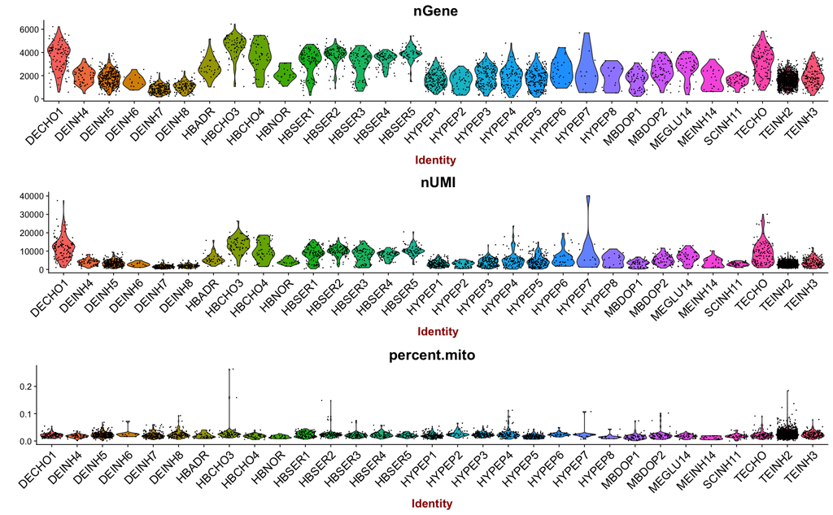

```r
VlnPlot(object = zeisel.ob,
        features.plot = c("nGene", "nUMI", "percent.mito"),
        nCol = 1,
        point.size.use = 0,
        x.lab.rot = TRUE)
```

```r
summary(zeisel.ob@meta.data$percent.mito)
```

```
   Min. 1st Qu.  Median    Mean 3rd Qu.    Max.
0.00000 0.01552 0.02110 0.02307 0.02761 0.26337
```

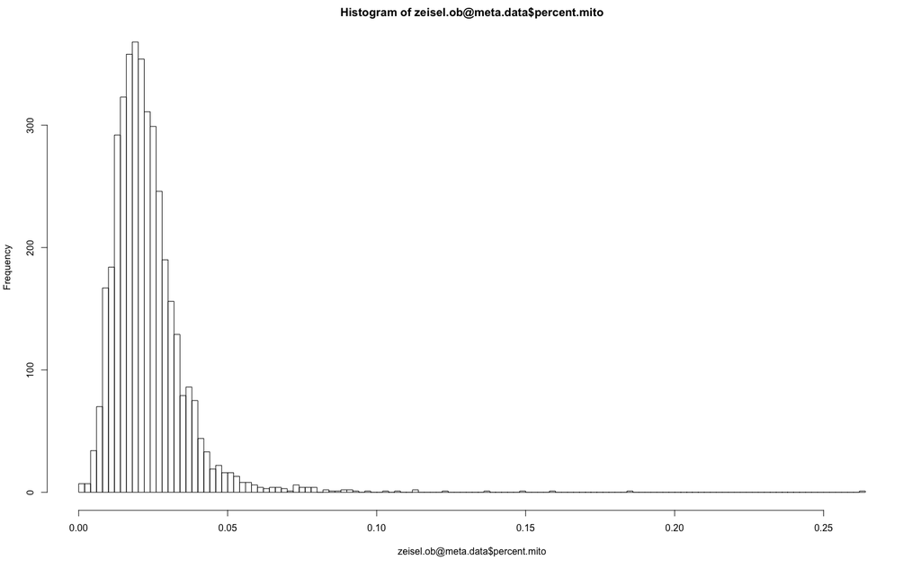

```r
hist(zeisel.ob@meta.data$percent.mito, breaks = 100)
```

```r
summary(zeisel.ob@meta.data$nUMI)
```

```
   Min. 1st Qu.  Median    Mean 3rd Qu.    Max.
    160    2135    3325    4618    5550   40100
```

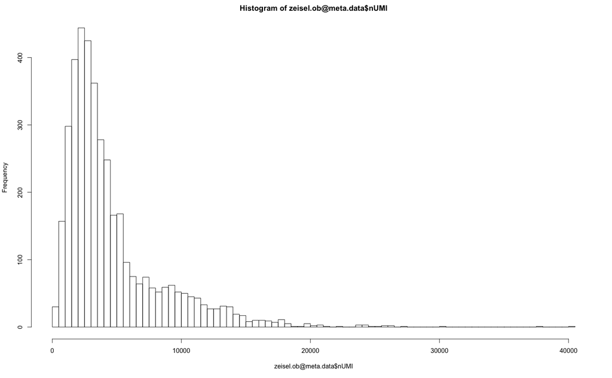

```r
hist(zeisel.ob@meta.data$nUMI, breaks = 100)
```

```r
summary(zeisel.ob@meta.data$nGene)
```

```
   Min. 1st Qu.  Median    Mean 3rd Qu.    Max.
    120    1256    1810    2052    2594    6447
```

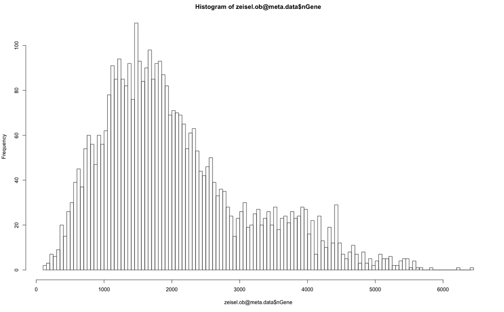

```r
hist(zeisel.ob@meta.data$nGene, breaks = 100)
```

## 4. Save the Seurat object for later analysis

```r
saveRDS(object = zeisel.ob,
        file = "/Volumes/LaCie/Dropbox/Sabatini Lab/DRN Cell Types Project/DRN Cell Types Manuscript/Revisions (1)/RNA-seq/zeisel_Seurat_cholinergic_monoaminergic_peptidergic.rds")
```

## Session Information

Machine specifications:

- Mac Pro (Late 2013)
- macOS High Sierra 10.13.4
- 3.7 GHz Quad-Core Intel Xeon E5
- 64 GB 1866 MHz DDR3
- Java version “1.8.0_172”

```
 setting  value
 version  R version 3.4.4 (2018-03-15)
 system   x86_64, darwin15.6.0
 ui       RStudio (1.1.447)
 language (EN)
 collate  en_US.UTF-8
 tz       America/New_York
 date     2019-04-30
```

```
Packages ----------------------------------------------------------------------------------------------
```

```
 package       * version    date       source
 abind           1.4-5      2016-07-21 CRAN (R 3.4.0)
 acepack         1.4.1      2016-10-29 cran (@1.4.1)
 ape             5.1        2018-04-04 CRAN (R 3.4.4)
 assertthat      0.2.0      2017-04-11 CRAN (R 3.4.0)
 backports       1.1.2      2017-12-13 CRAN (R 3.4.3)
 base          * 3.4.4      2018-03-15 local
 base64enc       0.1-3      2015-07-28 cran (@0.1-3)
 bindr           0.1.1      2018-03-13 CRAN (R 3.4.4)
 bindrcpp        0.2.2      2018-03-29 CRAN (R 3.4.4)
 bit             1.1-14     2018-05-29 CRAN (R 3.4.4)
 bit64           0.9-7      2017-05-08 CRAN (R 3.4.0)
 bitops          1.0-6      2013-08-17 cran (@1.0-6)
 broom           0.4.4      2018-03-29 CRAN (R 3.4.4)
 caret           6.0-80     2018-05-26 CRAN (R 3.4.4)
 caTools         1.17.1     2014-09-10 cran (@1.17.1)
 checkmate       1.8.5      2017-10-24 CRAN (R 3.4.2)
 class           7.3-14     2015-08-30 CRAN (R 3.4.4)
 cluster         2.0.7-1    2018-04-09 CRAN (R 3.4.4)
 codetools       0.2-15     2016-10-05 CRAN (R 3.4.4)
 colorspace      1.3-2      2016-12-14 CRAN (R 3.4.0)
 compiler        3.4.4      2018-03-15 local
 cowplot       * 0.9.2      2017-12-17 CRAN (R 3.4.3)
 CVST            0.2-2      2018-05-26 CRAN (R 3.4.4)
 data.table      1.10.4-3   2017-10-27 CRAN (R 3.4.2)
 datasets      * 3.4.4      2018-03-15 local
 ddalpha         1.3.2      2018-04-08 CRAN (R 3.4.4)
 DEoptimR        1.0-8      2016-11-19 cran (@1.0-8)
 devtools      * 1.13.5     2018-02-18 CRAN (R 3.4.3)
 diffusionMap    1.1-0      2014-02-20 cran (@1.1-0)
 digest          0.6.15     2018-01-28 CRAN (R 3.4.3)
 dimRed          0.1.0      2017-05-04 CRAN (R 3.4.0)
 diptest         0.75-7     2016-12-05 cran (@0.75-7)
 doSNOW          1.0.16     2017-12-13 CRAN (R 3.4.3)
 dplyr         * 0.7.5      2018-05-19 CRAN (R 3.4.4)
 DRR             0.0.3      2018-01-06 CRAN (R 3.4.3)
 dtw             1.20-1     2018-05-18 CRAN (R 3.4.4)
 evaluate        0.10.1     2017-06-24 cran (@0.10.1)
 fitdistrplus    1.0-9      2017-03-24 CRAN (R 3.4.0)
 flexmix         2.3-14     2017-04-28 cran (@2.3-14)
```

[output cut: 100 more lines]

```
 survival        2.42-3     2018-04-16 CRAN (R 3.4.4)
 tclust          1.4-1      2018-05-24 CRAN (R 3.4.4)
 tibble          1.4.2      2018-01-22 CRAN (R 3.4.3)
 tidyr           0.8.1      2018-05-18 CRAN (R 3.4.4)
 tidyselect      0.2.4      2018-02-26 CRAN (R 3.4.3)
 timeDate        3043.102   2018-02-21 CRAN (R 3.4.3)
 tools           3.4.4      2018-03-15 local
 trimcluster     0.1-2      2012-10-29 cran (@0.1-2)
 tsne            0.1-3      2016-07-15 cran (@0.1-3)
 useful        * 1.2.4      2018-05-21 CRAN (R 3.4.4)
 utils         * 3.4.4      2018-03-15 local
 VGAM            1.0-5      2018-02-07 CRAN (R 3.4.3)
 withr           2.1.2      2018-03-15 CRAN (R 3.4.4)
 yaml            2.1.19     2018-05-01 CRAN (R 3.4.4)
 zoo             1.8-1      2018-01-08 CRAN (R 3.4.3)
```